# DA1003_TimeSeries slides

```python
%%HTML
<script>
    var code_show=true; //true -> hide code at first

    function code_toggle() {
        $('div.prompt').show(); // always hide prompt
        if (code_show){
            $('div.input').hide();
        } else {
            $('div.input').show();
        }
        code_show = !code_show
    }
    $( document ).ready(code_toggle);
</script>
```

```python
%%HTML
<a href="javascript:code_toggle()">[Toggle Code]</a>
```

[Toggle Code]

```python
from IPython.display import display, HTML

CSS = """
.output {
    flex-direction: row;
}
"""

HTML('<style>{}</style>'.format(CSS))
```

```python
from __future__ import division
from pandas import Series, DataFrame
import pandas as pd
from numpy.random import randn
import numpy as np
pd.options.display.max_rows = 12
np.set_printoptions(precision=4, suppress=True)
import matplotlib.pyplot as plt
plt.rc('figure', figsize=(12, 8))
```

# 시계열

## 기간과 기간 연산

몇 일, 몇 개월, 몇 분기, 몇 해 같은 기간은 Period 클래스로 표현할 수 있으며 문자열이나 정수 그리고 빈도를 가지고 생성한다.

```python
p = pd.Period(2007, freq='A-DEC')
p
```

```
Period('2007', 'A-DEC')
```

위의 p 객체는 2007년 1월 1일부터 같은 해 12월 31일까지의 기간을 뜻한다. 이 기간에 정수를 더하거나 빼서 편리하게 정해진 빈도에 따라 기간을 이동시킬 수 있다.

```python
p + 5
```

```
Period('2012', 'A-DEC')
```

```python
p - 2
```

```
Period('2005', 'A-DEC')
```

두개의 Period 객체가 같은 빈도를 갖는다면 두 기간의 차는 둘 사이의 간격이 됨.

```python
pd.Period('2014', freq='A-DEC') - p
```

```
7
```

PeriodIndex는 period_range 함수를 이용하여 생성할 수 있다.

```python
rng = pd.period_range('1/1/2000', '6/30/2000', freq='M')
rng
```

```
PeriodIndex(['2000-01', '2000-02', '2000-03', '2000-04', '2000-05', '2000-06'], dtype='period[M]', freq='M')
```

PeriodIndex 객체는 순차적인 기간을 저장하며 다른 pandas 자료구조에서의 색인과 동일하게 사용된다.

```python
Series(np.random.randn(6), index=rng)
```

```
2000-01    0.104013
2000-02   -0.022695
2000-03   -1.078605
2000-04   -0.579381
2000-05   -1.411050
2000-06   -0.431820
Freq: M, dtype: float64
```

다음의 values와 같은 문자열의 배열을 이용해 PeriodIndex 객체를 생성할 수도 있다.

```python
values = ['2001Q3', '2002Q2', '2003Q1']
index = pd.PeriodIndex(values, freq='Q-DEC')
index
```

```
PeriodIndex(['2001Q3', '2002Q2', '2003Q1'], dtype='period[Q-DEC]', freq='Q-DEC')
```

### Period의 빈도 변환

기간과 PeriodIndex 객체는 asfreq 메소드를 이용해 다른 빈도로 변환할 수 있다.

새해 첫날부터 시작하는 연간 빈도를 월간 빈도로 변환해보자.

```python
p = pd.Period('2007', freq='A-DEC')
p
```

```
Period('2007', 'A-DEC')
```

```python
p.asfreq('M', how='start')
```

```
Period('2007-01', 'M')
```

```python
p.asfreq('M', how='end')
```

```
Period('2007-12', 'M')
```

Period('2007', 'A-DEC')는 전체 기간에 대해 커서로 생각할 수 있고 월간으로 다시 나눌 수 있다.

(420쪽 그림 10-1 참고)

[figure not shown]

회계 연도 마감이 12월이 아닌 경우에는 월간 빈도가 달라진다.

```python
p = pd.Period('2007', freq='A-JUN')
p.asfreq('M', 'start')
```

```
Period('2006-07', 'M')
```

```python
p.asfreq('M', 'end')
```

```
Period('2007-06', 'M')
```

빈도가 상위 단계에서 하위 단계로 변환되는 경우 상위 기간은 하위 기간이 어디에 속했는지에 따라 결정된다. 예를 들어 A-JUN 빈도일 경우 2007년 8월은 실제로 2008년 기간에 속하게 된다.

```python
p = pd.Period('Aug-2007', 'M')
p.asfreq('A-JUN')
```

```
Period('2008', 'A-JUN')
```

모든 PeriodIndex 객체나 TimeSeries는 asfreq 메소드를 사용하여 변환할 수 있다.

```python
rng = pd.period_range('2006', '2009', freq='A-DEC')
ts = Series(np.random.randn(len(rng)), index=rng)
ts
```

```
2006    1.129345
2007    0.322209
2008   -0.929032
2009   -1.522625
Freq: A-DEC, dtype: float64
```

```python
ts.asfreq('M', how='start')
```

```
2006-01    1.129345
2007-01    0.322209
2008-01   -0.929032
2009-01   -1.522625
Freq: M, dtype: float64
```

```python
ts.asfreq('B', how='end')
```

```
2006-12-29    1.129345
2007-12-31    0.322209
2008-12-31   -0.929032
2009-12-31   -1.522625
Freq: B, dtype: float64
```

### 분기 빈도

- 분기 데이터는 재정, 금융 및 다른 분야에서 표준으로 사용된다.
- 많은 분기 데이터는 일반적으로 회계 연도의 끝인 한 해의 12월 마지막 날이나 마지막 업무일을 기준으로 보고하는데, 2012Q4는 회계 연도의 끝이 어딘가에 따라 의미가 달라진다.
- pandas는 12가지 모든 경우의 수를 지원하며 분기 빈도는 Q-JAN부터 Q-DEC까지이다.

```python
p = pd.Period('2012Q4', freq='Q-JAN')
p
```

```
Period('2012Q4', 'Q-JAN')
```

회계 연도 마감이 1월인 경우라면 2012Q4는 11월부터 1월까지가 되고 일간 빈도로 검사할 수 있다.

(421쪽 그림 10-2 다양한 분기 빈도 변환 참고)

[figure not shown]

```python
p.asfreq('D', 'start')
```

```
Period('2011-11-01', 'D')
```

```python
p.asfreq('D', 'end')
```

```
Period('2012-01-31', 'D')
```

예를 들어 분기 영업 마감일의 오후 4시를 가리키는 타임스탬프는 다음과 같이 구할 수 있다.

```python
p4pm = (p.asfreq('B', 'e') - 1).asfreq('T', 's') + 16 * 60
p4pm
```

```
Period('2012-01-30 16:00', 'T')
```

```python
p4pm.to_timestamp()
```

```
Timestamp('2012-01-30 16:00:00')
```

period_range를 사용해 분기 범위를 생성하는 것도 가능하다.

```python
rng = pd.period_range('2011Q3', '2012Q4', freq='Q-JAN')
ts = Series(np.arange(len(rng)), index=rng)
display(rng)
ts
```

```
PeriodIndex(['2011Q3', '2011Q4', '2012Q1', '2012Q2', '2012Q3', '2012Q4'], dtype='period[Q-JAN]', freq='Q-JAN')
```

```
2011Q3    0
2011Q4    1
2012Q1    2
2012Q2    3
2012Q3    4
2012Q4    5
Freq: Q-JAN, dtype: int32
```

```python
display(rng.asfreq('B', 'e'))
new_rng = (rng.asfreq('B', 'e') - 1).asfreq('T', 's') + 16 * 60 # Begin->end, Minute->second 변경
new_rng
```

```
PeriodIndex(['2010-10-29', '2011-01-31', '2011-04-29', '2011-07-29',
             '2011-10-31', '2012-01-31'],
            dtype='period[B]', freq='B')
```

```
PeriodIndex(['2010-10-28 16:00', '2011-01-28 16:00', '2011-04-28 16:00',
             '2011-07-28 16:00', '2011-10-28 16:00', '2012-01-30 16:00'],
            dtype='period[T]', freq='T')
```

```python
rng.asfreq?
```

```
Signature: rng.asfreq(freq=None, how='E')
Docstring:
Convert the PeriodIndex to the specified frequency `freq`.

Parameters
----------

freq : str
    a frequency
how : str {'E', 'S'}
    'E', 'END', or 'FINISH' for end,
    'S', 'START', or 'BEGIN' for start.
    Whether the elements should be aligned to the end
    or start within pa period. January 31st ('END') vs.
    Janury 1st ('START') for example.
```

```python
ts.index = new_rng.to_timestamp()
ts
```

```
2010-10-28 16:00:00    0
2011-01-28 16:00:00    1
2011-04-28 16:00:00    2
2011-07-28 16:00:00    3
2011-10-28 16:00:00    4
2012-01-30 16:00:00    5
dtype: int32
```

### 타임스탬프와 기간 서로 표현하기

타임스탬프로 색인된 Series와 DataFrame 객체는 to_period 메소드를 사용해 Period로 변환할 수 있다.

```python
rng = pd.date_range('1/1/2000', periods=3, freq='M')
ts = Series(randn(3), index=rng)
pts = ts.to_period()
display(ts)
pts
```

```
2000-01-31   -1.443151
2000-02-29    0.410470
2000-03-31   -1.680655
Freq: M, dtype: float64
```

```
2000-01   -1.443151
2000-02    0.410470
2000-03   -1.680655
Freq: M, dtype: float64
```

여기서 말하는 기간은 겹치지 않는 시간상의 간격을 뜻하므로 주어진 빈도에서 타임스탬프는 하나의 기간에만 속한다. 새로운 PeriodIndex의 빈도는 기본적으로 타임스탬프 값을 통해 추론되지만 원하는 빈도를 직접 지정할 수도 있다. 극 결과로 중복되는 기간이 나오더라도 문제 되지 않는다.

```python
rng = pd.date_range('1/29/2000', periods=6, freq='D')
rng
```

```
DatetimeIndex(['2000-01-29', '2000-01-30', '2000-01-31', '2000-02-01',
               '2000-02-02', '2000-02-03'],
              dtype='datetime64[ns]', freq='D')
```

```python
ts2 = Series(randn(6), index=rng)
display(ts2.to_period())
ts2.to_period('M')
```

```
2000-01-29   -0.657370
2000-01-30    0.062334
2000-01-31   -0.542654
2000-02-01   -0.132435
2000-02-02   -1.379674
2000-02-03   -1.638746
Freq: D, dtype: float64
```

```
2000-01   -0.657370
2000-01    0.062334
2000-01   -0.542654
2000-02   -0.132435
2000-02   -1.379674
2000-02   -1.638746
Freq: M, dtype: float64
```

기간을 타임스탬프로 변환하려면 to_timestamp 메소드를 이용한다.

```python
pts = ts.to_period()
pts
```

```
2000-01   -1.443151
2000-02    0.410470
2000-03   -1.680655
Freq: M, dtype: float64
```

```python
pts.to_timestamp(how='end')
```

```
2000-01-31   -1.443151
2000-02-29    0.410470
2000-03-31   -1.680655
Freq: M, dtype: float64
```

### 배열을 이용해 PeriodIndex 생성하기

```python
data = pd.read_csv('ch08/macrodata.csv')
data.year
```

```
0      1959.0
1      1959.0
2      1959.0
3      1959.0
4      1960.0
5      1960.0
        ...
197    2008.0
198    2008.0
199    2008.0
200    2009.0
201    2009.0
202    2009.0
Name: year, Length: 203, dtype: float64
```

```python
data.quarter
```

```
0      1.0
1      2.0
2      3.0
3      4.0
4      1.0
5      2.0
      ...
197    2.0
198    3.0
199    4.0
200    1.0
201    2.0
202    3.0
Name: quarter, Length: 203, dtype: float64
```

```python
data.head()
```

|  | year | quarter | realgdp | realcons | realinv | realgovt | realdpi | cpi | m1 | tbilrate | unemp | pop | infl | realint |
| --- | --- | --- | --- | --- | --- | --- | --- | --- | --- | --- | --- | --- | --- | --- |
| 0 | 1959.0 | 1.0 | 2710.349 | 1707.4 | 286.898 | 470.045 | 1886.9 | 28.98 | 139.7 | 2.82 | 5.8 | 177.146 | 0.00 | 0.00 |
| 1 | 1959.0 | 2.0 | 2778.801 | 1733.7 | 310.859 | 481.301 | 1919.7 | 29.15 | 141.7 | 3.08 | 5.1 | 177.830 | 2.34 | 0.74 |
| 2 | 1959.0 | 3.0 | 2775.488 | 1751.8 | 289.226 | 491.260 | 1916.4 | 29.35 | 140.5 | 3.82 | 5.3 | 178.657 | 2.74 | 1.09 |
| 3 | 1959.0 | 4.0 | 2785.204 | 1753.7 | 299.356 | 484.052 | 1931.3 | 29.37 | 140.0 | 4.33 | 5.6 | 179.386 | 0.27 | 4.06 |
| 4 | 1960.0 | 1.0 | 2847.699 | 1770.5 | 331.722 | 462.199 | 1955.5 | 29.54 | 139.6 | 3.50 | 5.2 | 180.007 | 2.31 | 1.19 |

이 배열을 PeriodIndex에 빈도 값과 함께 전달하면 이를 조합해서 DataFrame에서 사용할 수 있는 색인을 만들어낸다.

```python
index = pd.PeriodIndex(year=data.year, quarter=data.quarter, freq='Q-DEC')
index
```

```
PeriodIndex(['1959Q1', '1959Q2', '1959Q3', '1959Q4', '1960Q1', '1960Q2',
             '1960Q3', '1960Q4', '1961Q1', '1961Q2',
             ...
             '2007Q2', '2007Q3', '2007Q4', '2008Q1', '2008Q2', '2008Q3',
             '2008Q4', '2009Q1', '2009Q2', '2009Q3'],
            dtype='period[Q-DEC]', length=203, freq='Q-DEC')
```

```python
data.index = index
data.infl
```

```
1959Q1    0.00
1959Q2    2.34
1959Q3    2.74
1959Q4    0.27
1960Q1    2.31
1960Q2    0.14
          ...
2008Q2    8.53
2008Q3   -3.16
2008Q4   -8.79
2009Q1    0.94
2009Q2    3.37
2009Q3    3.56
Freq: Q-DEC, Name: infl, Length: 203, dtype: float64
```

## 리샘플링과 빈도 변환

리샘플링은 시계열의 빈도를 변환하는 과정을 말한다. 상위 빈도의 데이터를 하위 빈도로 집계하는 것을 다운 샘플링이라 하며 반대의 과정을 업샘플링이라고 한다. 모든 리샘플링이 이 두가지 범주에 들어가는 것은 아니다. 예를 들어 W-WED을 W-FRI로 변경하는 것은 업샘플링도 다운샘플링도 아니다.

pandas 객체는 resample 메소드가 있어 이러한 작업에 사용할 수 있다.

```python
rng = pd.date_range('1/1/2000', periods=100, freq='D')
ts = Series(randn(len(rng)), index=rng)
# ts.resample('M', how='mean')
ts.resample('M').mean()
```

```
2000-01-31    0.295853
2000-02-29   -0.144582
2000-03-31    0.061627
2000-04-30   -0.377260
Freq: M, dtype: float64
```

```python
ts.resample('M', kind='period').mean()
```

[output not shown]

resample은 유연한 고수준의 메소드로, 매우 큰 시계열 데이터를 처리할 수 있다.

```python
ts.resample?
```

```
Signature: ts.resample(rule, how=None, axis=0, fill_method=None, closed=None, label=None, convention='start', kind=None, loffset=None, limit=None, base=0, on=None, level=None)
Docstring:
Convenience method for frequency conversion and resampling of time
series.  Object must have a datetime-like index (DatetimeIndex,
PeriodIndex, or TimedeltaIndex), or pass datetime-like values
to the on or level keyword.

Parameters
----------
rule : string
    the offset string or object representing target conversion
axis : int, optional, default 0
closed : {'right', 'left'}
    Which side of bin interval is closed. The default is 'left'
    for all frequency offsets except for 'M', 'A', 'Q', 'BM',
    'BA', 'BQ', and 'W' which all have a default of 'right'.
label : {'right', 'left'}
    Which bin edge label to label bucket with. The default is 'left'
    for all frequency offsets except for 'M', 'A', 'Q', 'BM',
    'BA', 'BQ', and 'W' which all have a default of 'right'.
convention : {'start', 'end', 's', 'e'}
    For PeriodIndex only, controls whether to use the start or end of
    `rule`
loffset : timedelta
    Adjust the resampled time labels
base : int, default 0
    For frequencies that evenly subdivide 1 day, the "origin" of the
    aggregated intervals. For example, for '5min' frequency, base could
    range from 0 through 4. Defaults to 0
on : string, optional
    For a DataFrame, column to use instead of index for resampling.
    Column must be datetime-like.

    .. versionadded:: 0.19.0

level : string or int, optional
    For a MultiIndex, level (name or number) to use for
    resampling.  Level must be datetime-like.

    .. versionadded:: 0.19.0
```

### 다운샘플링

- 시계열 데이터를 규칙적인 하위 빈도로 집계하는 일을 다운샘플링이라 한다.
- 집계할 데이터는 고정 빈도를 가질 필요도 없으며 잘라낸 시계열 조각의 크기를 원하는 빈도로 정의한다.
- 예를 들어 'M'이나 'BM'같은 월간 빈도로 변환하려면 데이터를 월 간격으로 나눠야 한다.
- 각 간격은 한쪽이 열려 있게 되는데, 이는 하나의 간격에서 양 끝 중에서 한쪽만 포함된다는 뜻이다.
- 그러면 각 간격의 모음이 전체 시계열이 된다.

다음은 resample을 사용해서 데이터를 다운샘플링할 때 고려해야 할 사항이다.

- 각 간격의 양 끝 중에서 열어둘 쪽
- 집계하려는 구간의 라벨을 간격의 시작으로 할지 끝으로 할지의 여부

```python
rng = pd.date_range('1/1/2000', periods=12, freq='T')
ts = Series(np.arange(12), index=rng)
ts
```

```
2000-01-01 00:00:00     0
2000-01-01 00:01:00     1
2000-01-01 00:02:00     2
2000-01-01 00:03:00     3
2000-01-01 00:04:00     4
2000-01-01 00:05:00     5
2000-01-01 00:06:00     6
2000-01-01 00:07:00     7
2000-01-01 00:08:00     8
2000-01-01 00:09:00     9
2000-01-01 00:10:00    10
2000-01-01 00:11:00    11
Freq: T, dtype: int32
```

ts를 5분 단위로 묶어서 각 그룹의 합을 구해보자.

```python
ts.resample('5min').sum()
# note: output changed (as the default changed from closed='right', label='right' to closed='left', label='left'
```

```
2000-01-01 00:00:00    10
2000-01-01 00:05:00    35
2000-01-01 00:10:00    21
Freq: 5T, dtype: int32
```

인자로 넘긴 '5min'은 5분 단위로 증가하는 그룹의 경계를 정의한다. 기본적으로 시작 값을 그룹의 왼쪽에 포함시키므로 closed='right'를 넘기면 시작 값을 그룹의 오른쪽에 포함시킨다.

```python
ts.resample('5min', closed='right').sum()
```

```
1999-12-31 23:55:00     0
2000-01-01 00:00:00    15
2000-01-01 00:05:00    40
2000-01-01 00:10:00    11
Freq: 5T, dtype: int32
```

```python
ts.resample('5min', closed='right', label='right').sum()
```

```
2000-01-01 00:00:00     0
2000-01-01 00:05:00    15
2000-01-01 00:10:00    40
2000-01-01 00:15:00    11
Freq: 5T, dtype: int32
```

(428쪽 그림 10-3 참고)

[figure not shown]

반환된 결과의 색인을 특정 크기만큼 이동하고자 할 때, 즉, 그룹의 오른쪽 끝에서 1초를 빼서 타임스탬프가 참조하는 간격을 좀 더 명확히 보여주고자 할 때는 loffset 메소드에 문자열이나 날짜 오프셋을 넘기면 된다.

loffset 대신 반환된 결과에 shift 메소드를 사용해도 같은 결과를 얻을 수 있다.

```python
ts.resample('5min', loffset='-1s').sum()
```

```
1999-12-31 23:59:59    10
2000-01-01 00:04:59    35
2000-01-01 00:09:59    21
Freq: 5T, dtype: int32
```

```python
(ts.resample('5min').sum()).shift(-1, freq='s')
```

```
1999-12-31 23:59:59    10
2000-01-01 00:04:59    35
2000-01-01 00:09:59    21
Freq: 5T, dtype: int32
```

#### OHLC (Open-High-Low-Close) 리샘플링

금융 분야에서는 시계열 데이터를 시가(Open), 상한가(High), 하한가(Low), 종가(Close)를 기준으로 집계하는 경우가 많다. 이를 OHLC라고 하며 resample 메소드의 결과에 ohlc()를 이어붙여 사용한다.

```python
ts.resample('5min').ohlc()
# note: output changed because of changed defaults
```

|  | open | high | low | close |
| --- | --- | --- | --- | --- |
| 2000-01-01 00:00:00 | 0 | 4 | 0 | 4 |
| 2000-01-01 00:05:00 | 5 | 9 | 5 | 9 |
| 2000-01-01 00:10:00 | 10 | 11 | 10 | 11 |

#### GroupBy를 사용한 리샘플링

pandas의 groupby 메소드를 이용해서 다운샘플링하는 방법도 있다. 예를 들어 시계열 색인의 필드에 접근하는 함수를 전달해서 월이나 평일로 그룹을 지을 수 있다.

```python
rng = pd.date_range('1/1/2000', periods=100, freq='D')
ts = Series(np.arange(100), index=rng)
```

```python
ts.groupby(lambda x: x.month).mean()
```

```
1    15
2    45
3    75
4    95
dtype: int32
```

```python
ts.groupby(lambda x: x.weekday).mean()
```

```
0    47.5
1    48.5
2    49.5
3    50.5
4    51.5
5    49.0
6    50.0
dtype: float64
```

### 업샘플링과 보간

하위 빈도에서 상위 빈도로 변환할 때는 집계가 필요하지 않다. 주간 데이터를 담고 있는 다음의 DataFrame을 보자.

```python
frame = DataFrame(np.random.randn(2, 4),
                  index=pd.date_range('1/1/2000', periods=2, freq='W-WED'),
                  columns=['Colorado', 'Texas', 'New York', 'Ohio'])
frame
```

|  | Colorado | Texas | New York | Ohio |
| --- | --- | --- | --- | --- |
| 2000-01-05 | -1.758639 | 0.315652 | -1.215245 | 1.048867 |
| 2000-01-12 | 0.923145 | 0.970443 | 0.801145 | 0.420535 |

위의 데이터를 일 빈도로 리샘플링해보자. 한 주에 하나의 데이터 밖에 없는데 일 빈도로 업샘플링을 하면 누락 값이 생긴다. 집계함수 없이 업샘플링 할 때는 asfreq() 메소드를 사용한다.

```python
df_daily = frame.resample('D').asfreq()
df_daily
```

|  | Colorado | Texas | New York | Ohio |
| --- | --- | --- | --- | --- |
| 2000-01-05 | -1.758639 | 0.315652 | -1.215245 | 1.048867 |
| 2000-01-06 | NaN | NaN | NaN | NaN |
| 2000-01-07 | NaN | NaN | NaN | NaN |
| 2000-01-08 | NaN | NaN | NaN | NaN |
| 2000-01-09 | NaN | NaN | NaN | NaN |
| 2000-01-10 | NaN | NaN | NaN | NaN |
| 2000-01-11 | NaN | NaN | NaN | NaN |
| 2000-01-12 | 0.923145 | 0.970443 | 0.801145 | 0.420535 |

누락 값에 이전 값을 채우는 보간 메소드를 사용할 수 있다.

```python
frame.resample('D').ffill()
```

|  | Colorado | Texas | New York | Ohio |
| --- | --- | --- | --- | --- |
| 2000-01-05 | -1.758639 | 0.315652 | -1.215245 | 1.048867 |
| 2000-01-06 | -1.758639 | 0.315652 | -1.215245 | 1.048867 |
| 2000-01-07 | -1.758639 | 0.315652 | -1.215245 | 1.048867 |
| 2000-01-08 | -1.758639 | 0.315652 | -1.215245 | 1.048867 |
| 2000-01-09 | -1.758639 | 0.315652 | -1.215245 | 1.048867 |
| 2000-01-10 | -1.758639 | 0.315652 | -1.215245 | 1.048867 |
| 2000-01-11 | -1.758639 | 0.315652 | -1.215245 | 1.048867 |
| 2000-01-12 | 0.923145 | 0.970443 | 0.801145 | 0.420535 |

또한 limit 옵션을 사용해서 보간 범위를 지정할 수 있다.

```python
# frame.resample('D', fill_method='ffill', limit=2)
frame.resample('D').ffill(limit=2)
```

|  | Colorado | Texas | New York | Ohio |
| --- | --- | --- | --- | --- |
| 2000-01-05 | -1.758639 | 0.315652 | -1.215245 | 1.048867 |
| 2000-01-06 | -1.758639 | 0.315652 | -1.215245 | 1.048867 |
| 2000-01-07 | -1.758639 | 0.315652 | -1.215245 | 1.048867 |
| 2000-01-08 | NaN | NaN | NaN | NaN |
| 2000-01-09 | NaN | NaN | NaN | NaN |
| 2000-01-10 | NaN | NaN | NaN | NaN |
| 2000-01-11 | NaN | NaN | NaN | NaN |
| 2000-01-12 | 0.923145 | 0.970443 | 0.801145 | 0.420535 |

보간 메소드를 활용하면 누락 값을 효과적으로 채워주므로 새로운 날짜 색인이 원래의 색인과 겹칠 필요가 없다.

```python
frame.resample('W-THU').ffill()
```

|  | Colorado | Texas | New York | Ohio |
| --- | --- | --- | --- | --- |
| 2000-01-06 | -1.758639 | 0.315652 | -1.215245 | 1.048867 |
| 2000-01-13 | 0.923145 | 0.970443 | 0.801145 | 0.420535 |

### 기간 리샘플링

기간으로 색인된 데이터도 리샘플링이 가능한다.

```python
frame = DataFrame(np.random.randn(24, 4),
                  index=pd.period_range('1-2000', '12-2001', freq='M'),
                  columns=['Colorado', 'Texas', 'New York', 'Ohio'])
frame
```

|  | Colorado | Texas | New York | Ohio |
| --- | --- | --- | --- | --- |
| 2000-01 | 0.285675 | -0.778824 | 1.128203 | -0.709075 |
| 2000-02 | -1.520754 | -1.119986 | -0.129536 | -0.846266 |
| 2000-03 | -0.177819 | -1.995793 | 0.983609 | 0.094347 |
| 2000-04 | -0.080346 | 0.117212 | 0.381012 | -0.645830 |
| 2000-05 | 1.274687 | -0.427287 | -0.821034 | 0.218815 |
| 2000-06 | -0.774257 | 0.879371 | -0.543186 | 0.843256 |
| ... | ... | ... | ... | ... |
| 2001-07 | 1.064283 | 0.570927 | -1.789510 | -0.372165 |
| 2001-08 | -0.209894 | 0.083695 | -0.365288 | 0.071166 |
| 2001-09 | -0.383416 | 0.072164 | -0.807214 | 0.308332 |
| 2001-10 | 1.041725 | -0.915869 | -0.331111 | 2.305185 |
| 2001-11 | -0.714025 | -1.051736 | -0.352338 | -1.768208 |
| 2001-12 | 1.193095 | -1.650747 | 0.502615 | 0.670271 |

24 rows × 4 columns

```python
annual_frame = frame.resample('A-DEC').mean()
annual_frame
```

|  | Colorado | Texas | New York | Ohio |
| --- | --- | --- | --- | --- |
| 2000 | -0.227374 | 0.306497 | -0.112381 | -0.037206 |
| 2001 | 0.295729 | -0.478027 | -0.499383 | 0.024733 |

```python
# Q-DEC: 분기 구간, 연도 마감은 12월
display(annual_frame.resample('Q-DEC').asfreq())
annual_frame.resample('Q-DEC').ffill()
# note: output changed, default value changed from convention='end' to convention='start' + 'start' changed to span-like
# also the following cells
```

|  | Colorado | Texas | New York | Ohio |
| --- | --- | --- | --- | --- |
| 2000Q1 | -0.227374 | 0.306497 | -0.112381 | -0.037206 |
| 2000Q2 | NaN | NaN | NaN | NaN |
| 2000Q3 | NaN | NaN | NaN | NaN |
| 2000Q4 | NaN | NaN | NaN | NaN |
| 2001Q1 | 0.295729 | -0.478027 | -0.499383 | 0.024733 |
| 2001Q2 | NaN | NaN | NaN | NaN |
| 2001Q3 | NaN | NaN | NaN | NaN |
| 2001Q4 | NaN | NaN | NaN | NaN |

|  | Colorado | Texas | New York | Ohio |
| --- | --- | --- | --- | --- |
| 2000Q1 | -0.227374 | 0.306497 | -0.112381 | -0.037206 |
| 2000Q2 | -0.227374 | 0.306497 | -0.112381 | -0.037206 |
| 2000Q3 | -0.227374 | 0.306497 | -0.112381 | -0.037206 |
| 2000Q4 | -0.227374 | 0.306497 | -0.112381 | -0.037206 |
| 2001Q1 | 0.295729 | -0.478027 | -0.499383 | 0.024733 |
| 2001Q2 | 0.295729 | -0.478027 | -0.499383 | 0.024733 |
| 2001Q3 | 0.295729 | -0.478027 | -0.499383 | 0.024733 |
| 2001Q4 | 0.295729 | -0.478027 | -0.499383 | 0.024733 |

```python
display(annual_frame.resample('Q-DEC', convention='start').asfreq())
annual_frame.resample('Q-DEC', convention='s').ffill()
```

|  | Colorado | Texas | New York | Ohio |
| --- | --- | --- | --- | --- |
| 2000Q1 | -0.227374 | 0.306497 | -0.112381 | -0.037206 |
| 2000Q2 | NaN | NaN | NaN | NaN |
| 2000Q3 | NaN | NaN | NaN | NaN |
| 2000Q4 | NaN | NaN | NaN | NaN |
| 2001Q1 | 0.295729 | -0.478027 | -0.499383 | 0.024733 |
| 2001Q2 | NaN | NaN | NaN | NaN |
| 2001Q3 | NaN | NaN | NaN | NaN |
| 2001Q4 | NaN | NaN | NaN | NaN |

|  | Colorado | Texas | New York | Ohio |
| --- | --- | --- | --- | --- |
| 2000Q1 | -0.227374 | 0.306497 | -0.112381 | -0.037206 |
| 2000Q2 | -0.227374 | 0.306497 | -0.112381 | -0.037206 |
| 2000Q3 | -0.227374 | 0.306497 | -0.112381 | -0.037206 |
| 2000Q4 | -0.227374 | 0.306497 | -0.112381 | -0.037206 |
| 2001Q1 | 0.295729 | -0.478027 | -0.499383 | 0.024733 |
| 2001Q2 | 0.295729 | -0.478027 | -0.499383 | 0.024733 |
| 2001Q3 | 0.295729 | -0.478027 | -0.499383 | 0.024733 |
| 2001Q4 | 0.295729 | -0.478027 | -0.499383 | 0.024733 |

```python
display(annual_frame.resample('Q-DEC', convention='end').asfreq())
annual_frame.resample('Q-DEC', convention='e').bfill()
```

|  | Colorado | Texas | New York | Ohio |
| --- | --- | --- | --- | --- |
| 2000Q4 | -0.227374 | 0.306497 | -0.112381 | -0.037206 |
| 2001Q1 | NaN | NaN | NaN | NaN |
| 2001Q2 | NaN | NaN | NaN | NaN |
| 2001Q3 | NaN | NaN | NaN | NaN |
| 2001Q4 | 0.295729 | -0.478027 | -0.499383 | 0.024733 |

|  | Colorado | Texas | New York | Ohio |
| --- | --- | --- | --- | --- |
| 2000Q4 | -0.227374 | 0.306497 | -0.112381 | -0.037206 |
| 2001Q1 | 0.295729 | -0.478027 | -0.499383 | 0.024733 |
| 2001Q2 | 0.295729 | -0.478027 | -0.499383 | 0.024733 |
| 2001Q3 | 0.295729 | -0.478027 | -0.499383 | 0.024733 |
| 2001Q4 | 0.295729 | -0.478027 | -0.499383 | 0.024733 |

기간(periods)은 경과시간(timespans)을 참조하므로 업샘플링과 다운샘플링 규칙이 좀더 엄격하다.

- 다운샘플링에서는 대상 빈도가 원본 빈도의 하위 기간이어야 한다.
- 업샘플링에서는 대상 빈도가 원본 빈도의 상위 기간이어야 한다.

이 조건이 만족되지 않으면 예외가 발생한다. 이는 주로 분기별, 연간, 주간 빈도에 영향을 미치는데, 예를 들어, Q-MAR로 정의된 경과시간(timespans)은 오직 A-MAR, A-JUN, A-SEP, A-DEC에만 업샘플링이 가능하다.

```python
aa=annual_frame.resample('Q-MAR').ffill()
aa
```

|  | Colorado | Texas | New York | Ohio |
| --- | --- | --- | --- | --- |
| 2000Q4 | -0.227374 | 0.306497 | -0.112381 | -0.037206 |
| 2001Q1 | -0.227374 | 0.306497 | -0.112381 | -0.037206 |
| 2001Q2 | -0.227374 | 0.306497 | -0.112381 | -0.037206 |
| 2001Q3 | -0.227374 | 0.306497 | -0.112381 | -0.037206 |
| 2001Q4 | 0.295729 | -0.478027 | -0.499383 | 0.024733 |
| 2002Q1 | 0.295729 | -0.478027 | -0.499383 | 0.024733 |
| 2002Q2 | 0.295729 | -0.478027 | -0.499383 | 0.024733 |
| 2002Q3 | 0.295729 | -0.478027 | -0.499383 | 0.024733 |

```python
display(aa.resample('A-DEC').mean())
aa.resample('A-FEB').mean() # 'A-FEB'는 'Q-MAR'와 분기 정렬이 되지 않으므로 업샘플링 불가
```

|  | Colorado | Texas | New York | Ohio |
| --- | --- | --- | --- | --- |
| 2000 | -0.227374 | 0.306497 | -0.112381 | -0.037206 |
| 2001 | 0.295729 | -0.478027 | -0.499383 | 0.024733 |

```
---------------------------------------------------------------------------
IncompatibleFrequency                     Traceback (most recent call last)
<ipython-input-263-f1d7c321a52c> in <module>()
      1 display(aa.resample('A-DEC').mean())
----> 2 aa.resample('A-FEB').mean() # 'A-FEB'는 'Q-MAR'와 분기 정렬이 되지 않으므로 업샘플링 불가

C:\Anaconda3\lib\site-packages\pandas\core\resample.py in f(self, _method, *args, **kwargs)
    619     def f(self, _method=method, *args, **kwargs):
    620         nv.validate_resampler_func(_method, args, kwargs)
--> 621         return self._downsample(_method)
    622     f.__doc__ = getattr(GroupBy, method).__doc__
    623     setattr(Resampler, method, f)

C:\Anaconda3\lib\site-packages\pandas\core\resample.py in _downsample(self, how, **kwargs)
    910         raise IncompatibleFrequency(
    911             'Frequency {} cannot be resampled to {}, as they are not '
--> 912             'sub or super periods'.format(ax.freq, self.freq))
    913
    914     def _upsample(self, method, limit=None, fill_value=None):

IncompatibleFrequency: Frequency <QuarterEnd: startingMonth=3> cannot be resampled to <YearEnd: month=2>, as they are not sub or super periods
```

## 시계열 그래프

pandas의 시계열 그래프는 matplotlib으로 표현하는 것에 비해 개선된 데이터 포맷을 가지고 있다. 야후! 파이낸스에서 내려받은 몇몇 미국 주식의 주가 데이터를 살펴보자.

```python
close_px_all = pd.read_csv('ch09/stock_px.csv', parse_dates=True, index_col=0)
close_px = close_px_all[['AAPL', 'MSFT', 'XOM']]
# close_px = close_px.resample('B', fill_method='ffill')
close_px = close_px.resample('B').ffill()
close_px.info()
```

```
<class 'pandas.core.frame.DataFrame'>
DatetimeIndex: 2292 entries, 2003-01-02 to 2011-10-14
Freq: B
Data columns (total 3 columns):
AAPL    2292 non-null float64
MSFT    2292 non-null float64
XOM     2292 non-null float64
dtypes: float64(3)
memory usage: 71.6 KB
```

```python
close_px.head()
```

|  | AAPL | MSFT | XOM |
| --- | --- | --- | --- |
| 2003-01-02 | 7.40 | 21.11 | 29.22 |
| 2003-01-03 | 7.45 | 21.14 | 29.24 |
| 2003-01-06 | 7.45 | 21.52 | 29.96 |
| 2003-01-07 | 7.43 | 21.93 | 28.95 |
| 2003-01-08 | 7.28 | 21.31 | 28.83 |

애플('AAPL')의 일별 주가 그래프를 그려보자.

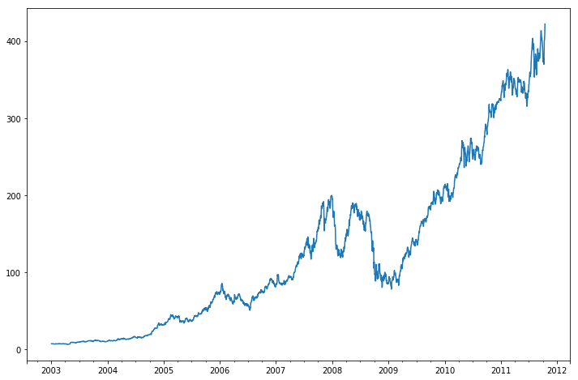

```python
close_px['AAPL'].plot()
plt.show()
```

DataFrame에 대해 plot 메소드를 호출하면 원하는 대로 모든 시계열이 하나의 그래프로 그려지고 범주를 통해 어떤 주식인지 표시해준다.

2009년의 데이터만 가지고 그래프를 그려보면 X축 라벨로 월과 년이 표시된다.

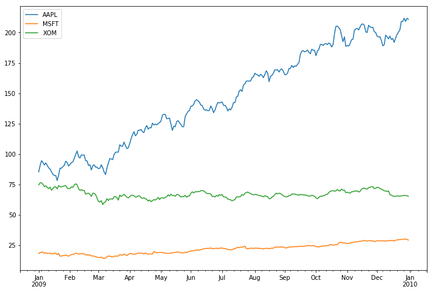

```python
close_px.loc['2009'].plot()
plt.show()
```

2011년 1월~2011년 3월 사이의 애플 사의 일별 주가

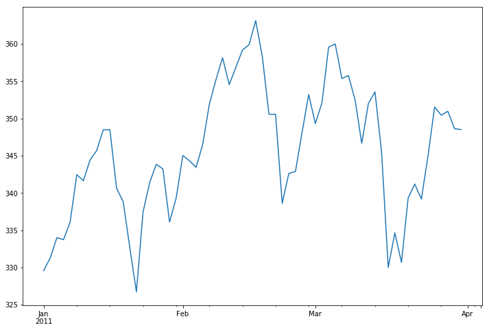

```python
close_px['AAPL'].loc['01-2011':'03-2011'].plot()
plt.show()
```

분기 단위의 데이터는 분기 표시와 함께 좀 더 깔끔하게 표시된다.

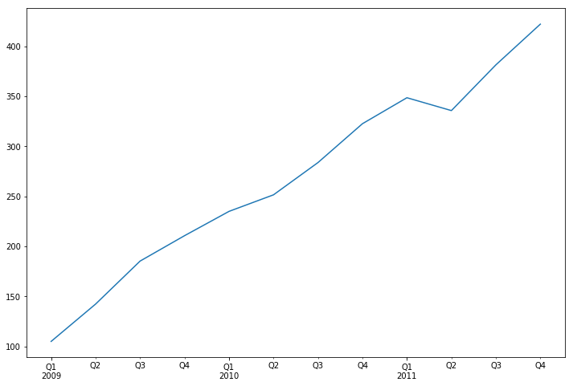

```python
appl_q = close_px['AAPL'].resample('Q-DEC').ffill()
appl_q.loc['2009':].plot()
plt.show()
```

```python
plt.close('all')
```

%matplotlib 설정을 notebook모드로 변경하면 상호작용 기능이 가능하다.

```python
%matplotlib notebook
```

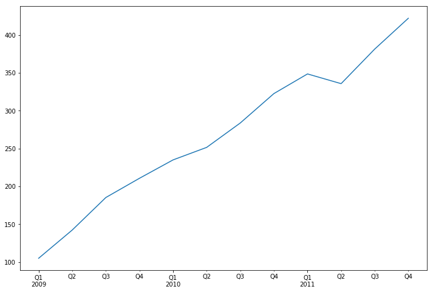

```python
plt.figure(figsize=(12,8))
appl_q.loc['2009':].plot()
plt.show()
```

```python
plt.close('all')
```

```python
%matplotlib inline
```

## Moving Window(이동 창) 기능

이동 창이나 지수가중 함수가 적용된 통계함수 또는 일반 함수를 이용하여 배열을 변형해야 하는 경우가 있다. 다른 통계 함수와 마찬가지로 이동 창 함수도 누락된 데이터를 자동으로 배제한다.

pandas의 이동 창 관련 메소드는 세 가지가 있다.

- rolling: Provides rolling window calculations.
  - DataFrame.rolling(window, min_periods=None, center=False, win_type=None, on=None, axis=0, closed=None)
- expanding: Provides expanding transformations.
  - DataFrame.expanding(min_periods=1, center=False, axis=0)
- ewm: Provides exponential weighted functions.
  - DataFrame.ewm(com=None, span=None, halflife=None, alpha=None, min_periods=0, adjust=True, ignore_na=False, axis=0)

```python
df = DataFrame({'B': [0, 1, 2, np.nan, 4]})
```

```python
display(df)
df.rolling(2).sum()
```

|  | B |
| --- | --- |
| 0 | 0.0 |
| 1 | 1.0 |
| 2 | 2.0 |
| 3 | NaN |
| 4 | 4.0 |

|  | B |
| --- | --- |
| 0 | NaN |
| 1 | 1.0 |
| 2 | 3.0 |
| 3 | NaN |
| 4 | NaN |

```python
display(df)
df.expanding(2).sum()
```

|  | B |
| --- | --- |
| 0 | 0.0 |
| 1 | 1.0 |
| 2 | 2.0 |
| 3 | NaN |
| 4 | 4.0 |

|  | B |
| --- | --- |
| 0 | NaN |
| 1 | 1.0 |
| 2 | 3.0 |
| 3 | 3.0 |
| 4 | 7.0 |

```python
display(df)
df.ewm(com=0.5).mean()
```

|  | B |
| --- | --- |
| 0 | 0.0 |
| 1 | 1.0 |
| 2 | 2.0 |
| 3 | NaN |
| 4 | 4.0 |

|  | B |
| --- | --- |
| 0 | 0.000000 |
| 1 | 0.750000 |
| 2 | 1.615385 |
| 3 | 1.615385 |
| 4 | 3.670213 |

시계열 데이터를 읽어들여 비즈니스 데이 빈도로 리샘플링하자.

```python
# close_px = close_px.asfreq('B').fillna(method='ffill')
close_px = close_px.resample('B').ffill()
```

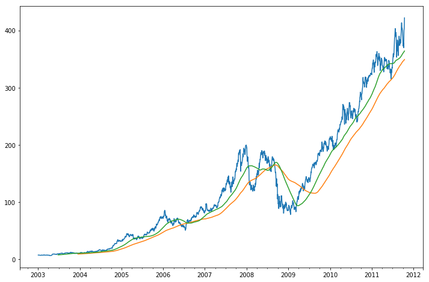

```python
close_px.AAPL.plot()
close_px.AAPL.rolling(window=250, center=False).mean().plot()
close_px.AAPL.rolling(window=125, center=False).mean().plot()
plt.show()
```

rolling(window=250)에서 250은 누락 값을 제외한 관측값의 개수이다. 위의 표현은 250개씩의 데이터에 대하여 평균을 구해 플롯한 것이다.

다음 rolling 메소드에서 min_periods=10을 지정한 결과인 appl_std250의 처음 몇 데이터는 누락 값을 포함한다.

```python
# appl_std250 = pd.rolling_std(close_px.AAPL, 250, min_periods=10)
appl_std250 = close_px.AAPL.rolling(250, min_periods=10).std()
appl_std250[5:12]
```

```
2003-01-09         NaN
2003-01-10         NaN
2003-01-13         NaN
2003-01-14         NaN
2003-01-15    0.077496
2003-01-16    0.074760
2003-01-17    0.112368
Freq: B, Name: AAPL, dtype: float64
```

```python
appl_std250
```

```
2003-01-02          NaN
2003-01-03          NaN
2003-01-06          NaN
2003-01-07          NaN
2003-01-08          NaN
2003-01-09          NaN
                ...
2011-10-07    25.412452
2011-10-10    25.430104
2011-10-11    25.523131
2011-10-12    25.624851
2011-10-13    25.758644
2011-10-14    25.993449
Freq: B, Name: AAPL, Length: 2292, dtype: float64
```

일별 애플 주가의 250일 표준편차

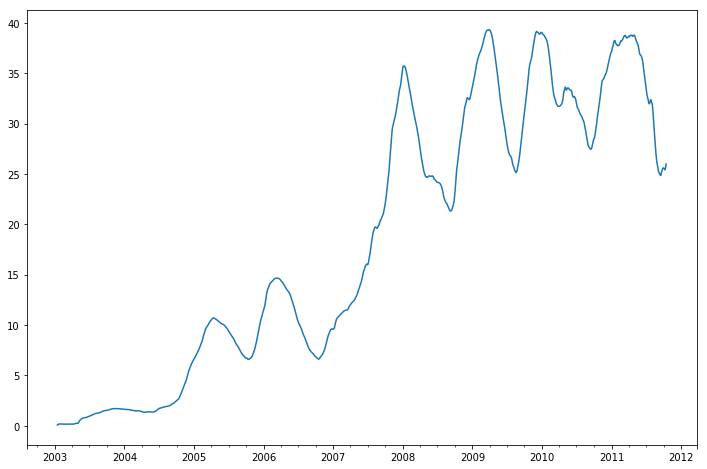

```python
appl_std250.plot()
plt.show()
```

확장 이동 창 평균을 계산하기 위해서는 rolling 대신 expanding 연산자를 사용한다. 확장 평균은 시계열의 시작지점부터 윈도우(창)을 시작하여 모든 데이터를 만나게 될 때까지 윈도우의 크기를 늘려나간다.

```python
appl_std250.expanding().mean()
```

```
2003-01-02          NaN
2003-01-03          NaN
2003-01-06          NaN
2003-01-07          NaN
2003-01-08          NaN
2003-01-09          NaN
                ...
2011-10-07    18.518168
2011-10-10    18.521201
2011-10-11    18.524272
2011-10-12    18.527385
2011-10-13    18.530554
2011-10-14    18.533823
Freq: B, Name: AAPL, Length: 2292, dtype: float64
```

```python
close_px.AAPL.expanding().mean()
```

```
2003-01-02      7.400000
2003-01-03      7.425000
2003-01-06      7.433333
2003-01-07      7.432500
2003-01-08      7.402000
2003-01-09      7.391667
                 ...
2011-10-07    124.729917
2011-10-10    124.845337
2011-10-11    124.965671
2011-10-12    125.086729
2011-10-13    125.210406
2011-10-14    125.339895
Freq: B, Name: AAPL, Length: 2292, dtype: float64
```

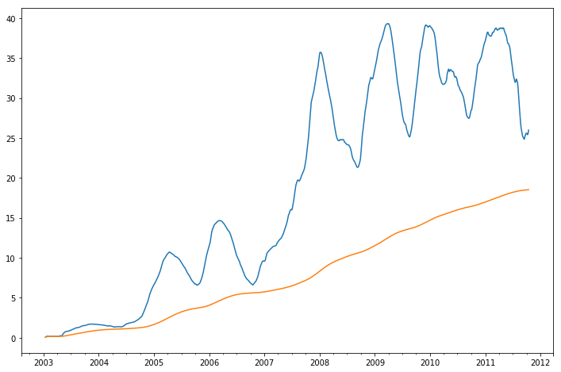

```python
appl_std250.plot()
appl_std250.expanding().mean().plot()
# close_px.AAPL.expanding(250).std().plot()
plt.show()
```

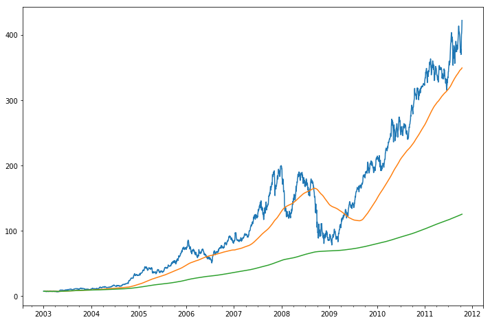

```python
close_px.AAPL.plot() # blue
close_px.AAPL.rolling(250, min_periods=10).mean().plot() # orange
close_px.AAPL.expanding().mean().plot() # green
plt.show()
```

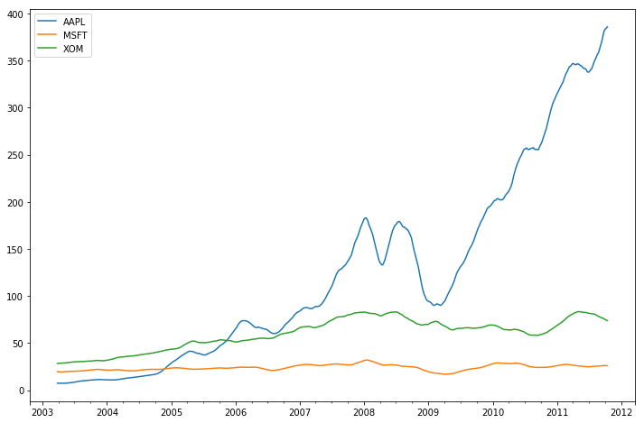

```python
# pd.rolling_mean(close_px, 60).plot(logy=True)
close_px.rolling(60).mean().plot()
plt.show()
```

rolling 메소드는 시간 오프셋을 나타내는 문자열도 window 사이즈로 허용하기 때문에 20일간의 이동 창의 평균을 표현하려면 다음과 같이 한다.

```python
close_px.rolling('20D').mean()
```

|  | AAPL | MSFT | XOM |
| --- | --- | --- | --- |
| 2003-01-02 | 7.400000 | 21.110000 | 29.220000 |
| 2003-01-03 | 7.425000 | 21.125000 | 29.230000 |
| 2003-01-06 | 7.433333 | 21.256667 | 29.473333 |
| 2003-01-07 | 7.432500 | 21.425000 | 29.342500 |
| 2003-01-08 | 7.402000 | 21.402000 | 29.240000 |
| 2003-01-09 | 7.391667 | 21.490000 | 29.273333 |
| ... | ... | ... | ... |
| 2011-10-07 | 392.479333 | 25.712000 | 72.454667 |
| 2011-10-10 | 389.351429 | 25.602143 | 72.527857 |
| 2011-10-11 | 388.505000 | 25.674286 | 72.835000 |
| 2011-10-12 | 388.531429 | 25.810000 | 73.400714 |
| 2011-10-13 | 388.826429 | 25.961429 | 73.905000 |
| 2011-10-14 | 391.038000 | 26.048667 | 74.185333 |

2292 rows × 3 columns

### 지수 가중 함수

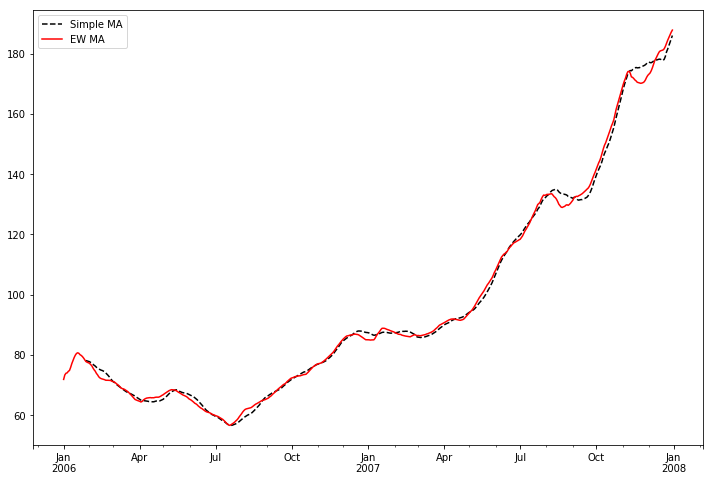

```python
aapl_px = close_px.AAPL['2006':'2007']
ma60 = aapl_px.rolling(30, min_periods=20).mean()
ewma60 = aapl_px.ewm(span=30).mean()
ma60.plot(style='k--', label='Simple MA')
ewma60.plot(style='r-', label= 'EW MA')
plt.legend()
plt.show()
```

### 이진 이동창 함수

상관관계와 공분산 같은 몇몇 통계연산은 2개의 시계열을 필요로 한다. 예를 들어, 금융 분석에 자주 참조되는 S&P 500과 같은 지수와 주식의 상관관계를 보자. 이는 rolling 메소드의 결과에 corr 메소드를 적용시켜 구할 수 있다.

```python
display(close_px)
spx_px = close_px_all['SPX']
spx_px
```

|  | AAPL | MSFT | XOM |
| --- | --- | --- | --- |
| 2003-01-02 | 7.40 | 21.11 | 29.22 |
| 2003-01-03 | 7.45 | 21.14 | 29.24 |
| 2003-01-06 | 7.45 | 21.52 | 29.96 |
| 2003-01-07 | 7.43 | 21.93 | 28.95 |
| 2003-01-08 | 7.28 | 21.31 | 28.83 |
| 2003-01-09 | 7.34 | 21.93 | 29.44 |
| ... | ... | ... | ... |
| 2011-10-07 | 369.80 | 26.25 | 73.56 |
| 2011-10-10 | 388.81 | 26.94 | 76.28 |
| 2011-10-11 | 400.29 | 27.00 | 76.27 |
| 2011-10-12 | 402.19 | 26.96 | 77.16 |
| 2011-10-13 | 408.43 | 27.18 | 76.37 |
| 2011-10-14 | 422.00 | 27.27 | 78.11 |

2292 rows × 3 columns

```
2003-01-02     909.03
2003-01-03     908.59
2003-01-06     929.01
2003-01-07     922.93
2003-01-08     909.93
2003-01-09     927.57
               ...
2011-10-07    1155.46
2011-10-10    1194.89
2011-10-11    1195.54
2011-10-12    1207.25
2011-10-13    1203.66
2011-10-14    1224.58
Name: SPX, Length: 2214, dtype: float64
```

6개월간 애플 사의 수익과 S&P 지수의 상관관계

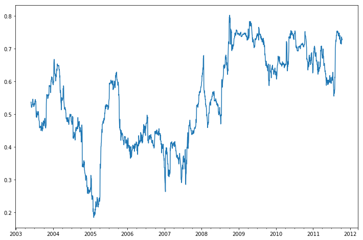

```python
spx_rets = spx_px / spx_px.shift(1) - 1
returns = close_px.pct_change()
# corr = pd.rolling_corr(returns.AAPL, spx_rets, 125, min_periods=100)
corr = returns.AAPL.rolling(125, min_periods=100).corr(spx_rets)
corr.plot()
plt.show()
```

6개월간 수익(주가의 퍼센트 변화율)과 S&P 500 지수의 상관관계

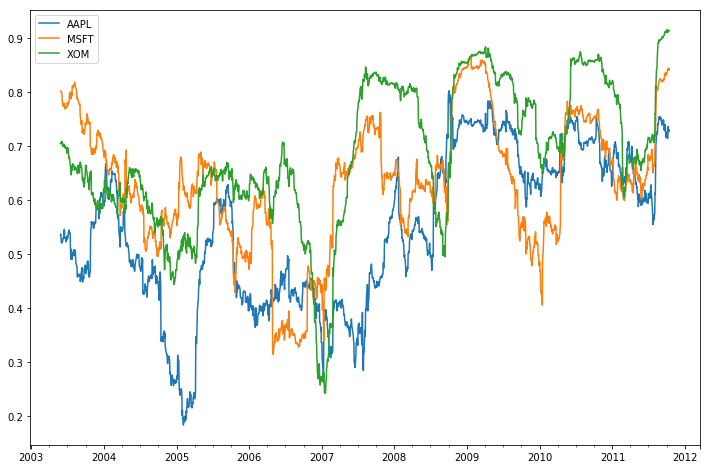

```python
# corr = pd.rolling_corr(returns, spx_rets, 125, min_periods=100)
corr = returns.rolling(125, min_periods=100).corr(spx_rets)
corr.plot()
plt.show()
```

### 사용자 정의 이동창 함수

rolling 메소드의 결과에 apply 메소드를 적용하면 사용자가 정의한 이동창 함수를 적용할 수 있다. 이 사용자 정의 함수는 배열을 입력으로 받아 차원이 감소된 단일 값을 결과로 반환해야 한다.

scipy.stats.percentileofscore 함수를 이용해 배열 x의 백분위 점수를 반환하는 함수를 이동창 함수로 적용해보자.

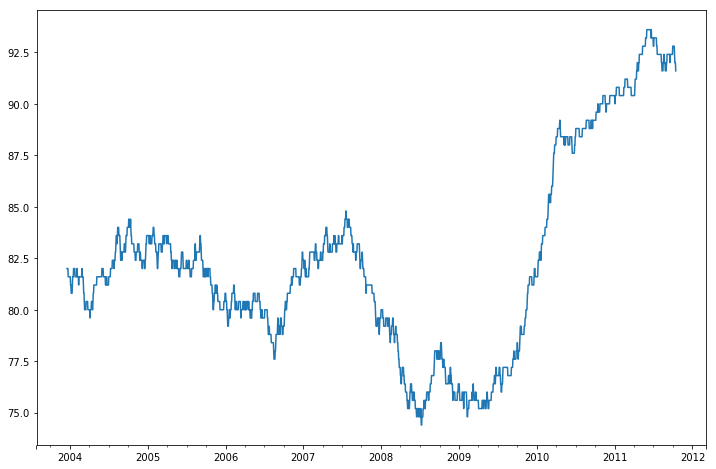

```python
from scipy.stats import percentileofscore
score_at_2percent = lambda x: percentileofscore(x, 0.02)
# result = pd.rolling_apply(returns.AAPL, 250, score_at_2percent)
result = returns.AAPL.rolling(250).apply(score_at_2percent)
result.plot()
plt.show()
```

## 성능과 메모리 사용량에 대한 노트

- 타임스탬프와 기간은 NumPy의 datetime64형을 사용해서 64비트 정수로 표현된다. 따라서 백만건의 float64 데이터를 가지는 시계열의 경우 대략적인 메모리 사용량은 16메가바이트가 된다.
- pandas는 시계열 간에 색인을 공유할 수 있도록 기존 시계열에 대한 뷰를 만들어 추가적인 메모리를 사용하지 않도록 하고 있다.
- 또한, 하위빈도에 대한 색인은 중앙 캐시에 저장되어 고정 빈도 색인은 날짜 캐시에 대한 뷰가 된다.
- 그렇기 때문에 대용량의 하위 빈도 시계열을 다루더라도 색인이 차지하는 메모리는 큰 문제가 되지 않는다.

성능 면에서는 pandas의 데이터 정렬 연산과 리샘플링은 고도로 최적화되어 있다. 예제를 통해 10MM개의 데이터를 OHLC로 집계해보자.

```python
rng = pd.date_range('1/1/2000', periods=10000000, freq='10ms')
ts = Series(np.random.randn(len(rng)), index=rng)
ts
```

```
2000-01-01 00:00:00.000   -1.046706
2000-01-01 00:00:00.010    0.491876
2000-01-01 00:00:00.020   -0.655944
2000-01-01 00:00:00.030    0.275307
2000-01-01 00:00:00.040    1.016895
2000-01-01 00:00:00.050   -0.587637
                             ...
2000-01-02 03:46:39.940    0.301699
2000-01-02 03:46:39.950   -0.886792
2000-01-02 03:46:39.960    1.577166
2000-01-02 03:46:39.970   -1.242012
2000-01-02 03:46:39.980    0.224732
2000-01-02 03:46:39.990   -0.624485
Freq: 10L, Length: 10000000, dtype: float64
```

```python
# ts.resample('15min', how='ohlc').info()
ts.resample('15min').ohlc().info()
```

```
<class 'pandas.core.frame.DataFrame'>
DatetimeIndex: 112 entries, 2000-01-01 00:00:00 to 2000-01-02 03:45:00
Freq: 15T
Data columns (total 4 columns):
open     112 non-null float64
high     112 non-null float64
low      112 non-null float64
close    112 non-null float64
dtypes: float64(4)
memory usage: 4.4 KB
```

```python
# %timeit ts.resample('15min', how='ohlc')
%timeit ts.resample('15min').ohlc()
```

```
121 ms ± 867 µs per loop (mean ± std. dev. of 7 runs, 10 loops each)
```

실행 시간은 집계되는 결과의 크기에 따라 상대적이므로 상위 빈도로 집계하는 데 더 오랜 시간이 걸린다.

```python
rng = pd.date_range('1/1/2000', periods=10000000, freq='1s')
ts = Series(np.random.randn(len(rng)), index=rng)
# %timeit ts.resample('15s', how='ohlc')
%timeit ts.resample('15s').ohlc()
```

```
188 ms ± 3.69 ms per loop (mean ± std. dev. of 7 runs, 1 loop each)
```